# 18. Window Functions

## French COVID-19

### Load the Data

We will be using the same data sets from the previous notebooks:

```r
dept <- read_sf(file.path("..", "data", "france_departement.geojson"))
pop <- read_csv(file.path("..", "data", "france_departement_population.csv"))
covid <- read_csv(file.path("..", "data", "france_departement_covid.csv"))
```

This time, we will look into the temporal components of the data and see how they can be integrated into the spatial visualisations.

### Window Functions

We will now look at a completely different way to work with time data. Rather than working directly with a date variable, we focus on working with an ordered set of data and associating each row with the rows before and after it. To start, let’s grab just a single département from the data, make sure that it is ordered by the date variable, and select just the variable hospitalized and the date.

```r
covid_paris <- covid %>%
  filter(departement_name == "Paris") %>%
  arrange(date) %>%
  select(date, hosp = hospitalised) # shortened name to better display below
covid_paris
```

```
## # A tibble: 198 × 2
##    date        hosp
##    <date>     <dbl>
##  1 2020-03-18   359
##  2 2020-03-19   453
##  3 2020-03-20   575
##  4 2020-03-21   649
##  5 2020-03-22   728
##  6 2020-03-23   925
##  7 2020-03-24  1076
##  8 2020-03-25  1289
##  9 2020-03-26  1493
## 10 2020-03-27  1656
## # … with 188 more rows
```

The function `lead` lets us associate a row in the data set with the value of a variable in the *following* row of data:

```r
covid_paris %>%
  mutate(hosp_next = lead(hosp))
```

```
## # A tibble: 198 × 3
##    date        hosp hosp_next
##    <date>     <dbl>     <dbl>
##  1 2020-03-18   359       453
##  2 2020-03-19   453       575
##  3 2020-03-20   575       649
##  4 2020-03-21   649       728
##  5 2020-03-22   728       925
##  6 2020-03-23   925      1076
##  7 2020-03-24  1076      1289
##  8 2020-03-25  1289      1493
##  9 2020-03-26  1493      1656
## 10 2020-03-27  1656      1927
## # … with 188 more rows
```

By default lead looks one row down, but we can set the option `n` to select a different offset. For example, looking a week into the future:

```r
covid_paris %>%
  mutate(hosp_next = lead(hosp), hosp_next_week = lead(hosp, n = 7))
```

```
## # A tibble: 198 × 4
##    date        hosp hosp_next hosp_next_week
##    <date>     <dbl>     <dbl>          <dbl>
##  1 2020-03-18   359       453           1289
##  2 2020-03-19   453       575           1493
##  3 2020-03-20   575       649           1656
##  4 2020-03-21   649       728           1927
##  5 2020-03-22   728       925           2115
##  6 2020-03-23   925      1076           2217
##  7 2020-03-24  1076      1289           2434
##  8 2020-03-25  1289      1493           2633
##  9 2020-03-26  1493      1656           2838
## 10 2020-03-27  1656      1927           2897
## # … with 188 more rows
```

The function `lag` works exactly the same way, but associates a row with the value of a variable in a *preceding* row. Note that the first row of data has a missing value because there is not previous row; we can change that with the option `default` (the same thing happens at the end of the data when using `lead`, it just was not as clear in the data print-out).

```r
covid_paris %>%
  mutate(hosp_last = lag(hosp), hosp_last_default = lag(hosp, default = 0))
```

```
## # A tibble: 198 × 4
##    date        hosp hosp_last hosp_last_default
##    <date>     <dbl>     <dbl>             <dbl>
##  1 2020-03-18   359        NA                 0
##  2 2020-03-19   453       359               359
##  3 2020-03-20   575       453               453
##  4 2020-03-21   649       575               575
##  5 2020-03-22   728       649               649
##  6 2020-03-23   925       728               728
##  7 2020-03-24  1076       925               925
##  8 2020-03-25  1289      1076              1076
##  9 2020-03-26  1493      1289              1289
## 10 2020-03-27  1656      1493              1493
## # … with 188 more rows
```

Other functions exist to do more complex relationships between rows. One that will be helpful for us here is `roll_meanr`, which takes the rolling average of a variable for a fixed number of values back in the table. For example, setting `n = 2` takes the average of each value of the hospitalization variable from each row and the preceding row:

```r
covid_paris %>%
  mutate(h_mean = roll_meanr(hosp, n = 2))
```

```
## # A tibble: 198 × 3
##    date        hosp h_mean
##    <date>     <dbl>  <dbl>
##  1 2020-03-18   359    NA
##  2 2020-03-19   453   406
##  3 2020-03-20   575   514
##  4 2020-03-21   649   612
##  5 2020-03-22   728   688.
##  6 2020-03-23   925   826.
##  7 2020-03-24  1076  1000.
##  8 2020-03-25  1289  1182.
##  9 2020-03-26  1493  1391
## 10 2020-03-27  1656  1574.
## # … with 188 more rows
```

There are variations `roll_meanl` and `roll_mean` for taking a rolling average with the future and symmetrically on either side. The `r` option (right) is the most appropriate for many kinds of time-series data.

We can see the effect of rolling averages in the following plot:

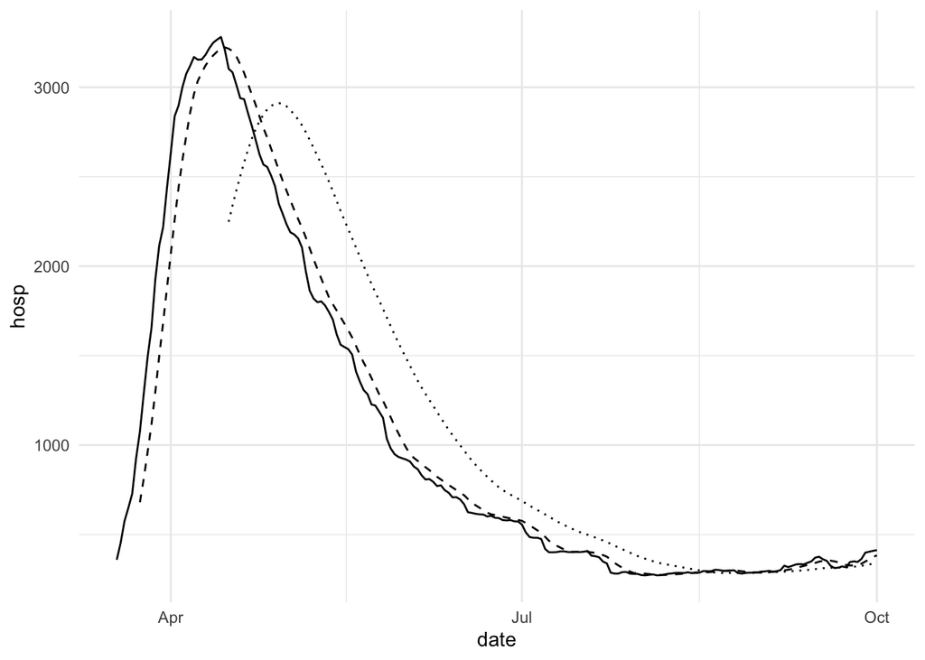

```r
covid_paris %>%
  mutate(
    h_mean_7 = roll_meanr(hosp, n = 7),
    h_sum_30 = roll_meanr(hosp, n = 30)
  ) %>%
  ggplot(aes(x = date, y = hosp)) +
    geom_line() +
    geom_line(aes(y = h_mean_7), linetype = "dashed") +
    geom_line(aes(y = h_sum_30), linetype = "dotted")
```

Notice that the peak occurs at a different date for the smoothed averages, but they are less noisy than the raw counts.